# Practical Machine Learning Project

E.T.Jaba Jasphin

June 21, 2015

In this project, my goal is to determine how well the participants are doing the barbell lifts and to use data from accelerometers on the belt, forearm, arm, and dumbell of 6 participants. The required Libraries are loded below

```r
library(caret)
library(ggplot2)
library(kernlab)
set.seed(33245)
```

For reading only the required data the following commands were used

```r
training<-read.csv("pml-training.csv")
testing<-read.csv("pml-testing.csv")

trainingdata<-c("accel_belt_x","accel_belt_y","accel_belt_z","accel_arm_x","accel_arm_y","accel_arm_z","accel_dumbbell_x","accel_dumbbell_y","accel_dumbbell_z","accel_forearm_x","accel_forearm_y","accel_forearm_z","user_name","classe")
testingdata<-c("accel_belt_x","accel_belt_y","accel_belt_z","accel_arm_x","accel_arm_y","accel_arm_z","accel_dumbbell_x","accel_dumbbell_y","accel_dumbbell_z","accel_forearm_x","accel_forearm_y","accel_forearm_z","user_name")

training1<-training[,trainingdata]
testing1<-testing[,testingdata]
```

Since our goal is to determine how well a participant is doing the barbell lifts, I have separated the data based on the user name and Created data partition for training and testing.

```r
x3<-subset(training1,user_name=="charles")
trainingcharles1<-x3[,-13]
inTraincharles<-createDataPartition(y=trainingcharles1$classe,p=0.75,list=FALSE);

trainingcharles<-trainingcharles1[inTraincharles,]
testingcharles<-trainingcharles1[-inTraincharles,]
```

Feature plot was created for some parameters which i have chosen for Charles.

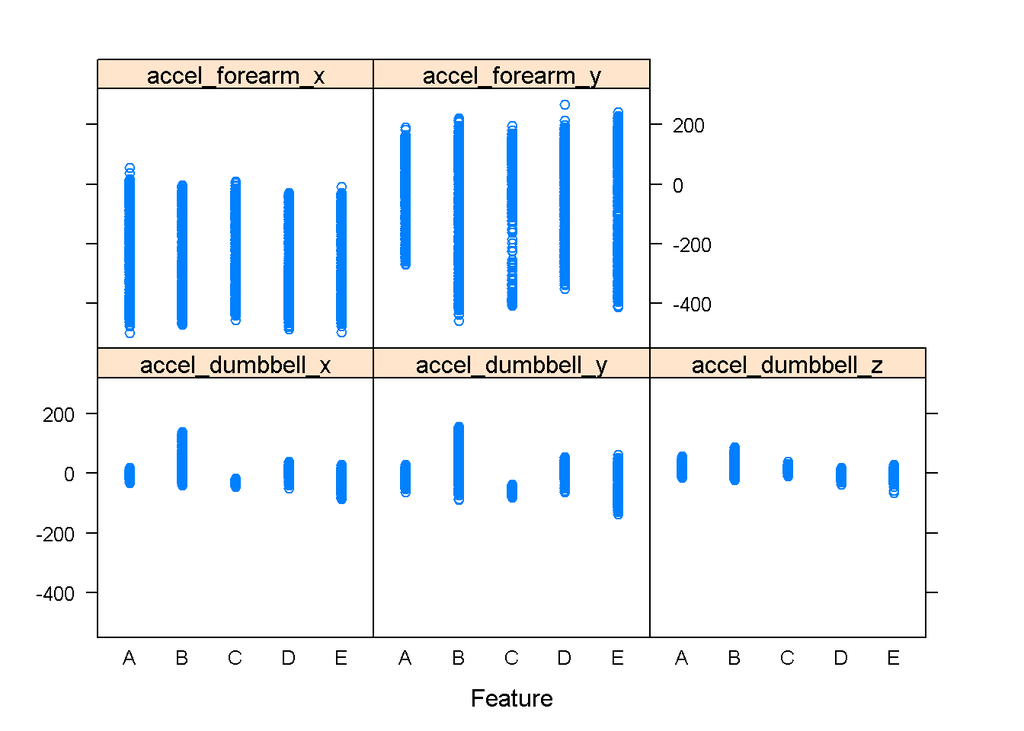

```r
featurePlot(x=trainingcharles[,c("accel_dumbbell_x","accel_dumbbell_y","accel_dumbbell_z","accel_forearm_x","accel_forearm_y")],y=trainingcharles$classe)
```

Model was created using the method rpart and gbm. If iam choosing rpart method accuracy was very less.So i have chosen the method gbm.For cross validation K-fold method was chosen and preprocessing was used with center and scale method.

```r
fitControl<-trainControl(method="repeatedcv",number=10,repeats=10)

modelFitcharles<-train(classe~.,data=trainingcharles,preProcess=c("center","scale"),trControl=fitControl,method="gbm",verbose=FALSE);
outputcharles<-predict(modelFitcharles,newdata=testingcharles)
confusionMatrix(testingcharles$classe,outputcharles)
```

```
## Confusion Matrix and Statistics
##
##           Reference
## Prediction   A   B   C   D   E
##          A 216   3   2   2   1
##          B   7 174   0   4   1
##          C   0   3 131   0   0
##          D   4   0   4 151   1
##          E   0   2   1   0 174
##
## Overall Statistics
##
##                Accuracy : 0.9603
##                  95% CI : (0.9452, 0.9722)
##     No Information Rate : 0.2577
##     P-Value [Acc > NIR] : < 2e-16
##
##                   Kappa : 0.95
##  Mcnemar's Test P-Value : 0.04565
##
## Statistics by Class:
##
##                      Class: A Class: B Class: C Class: D Class: E
## Sensitivity            0.9515   0.9560   0.9493   0.9618   0.9831
## Specificity            0.9878   0.9828   0.9960   0.9876   0.9957
## Pos Pred Value         0.9643   0.9355   0.9776   0.9437   0.9831
## Neg Pred Value         0.9833   0.9885   0.9906   0.9917   0.9957
## Prevalence             0.2577   0.2066   0.1566   0.1782   0.2009
## Detection Rate         0.2452   0.1975   0.1487   0.1714   0.1975
## Detection Prevalence   0.2543   0.2111   0.1521   0.1816   0.2009
## Balanced Accuracy      0.9697   0.9694   0.9726   0.9747   0.9894
```

Output for the person Charles in the given testing set is predicted as follows

```r
charles_classe<-predict(modelFitcharles,newdata=testing1[10,])
print(charles_classe)
```

```
## [1] A
## Levels: A B C D E
```

The above is the predicted classe for Charles in the testing set.